# A general pipeline for QTL mapping, using R/qtl and qtlTools

JT Lovell

2016-05-05

The following is a short description of a general way to analyze QTL experiments. This tutorial assumes that basic quality control, normalization and error checking have been completed. Also, permutations should have been calculated separately.

### Part 1: Set up the environment.

#### Load the necessary packages, install qtlTools from github

```r
library(devtools)
install_github("jtlovell/qtltools")
library(qtlTools)
library(qtl)
library(plyr)
```

#### Load the QTL data

For the purposes of this tutorial, we use the pre-loaded “multitrait” data from R/qtl. However, this would be the place to read in the cross object, permutations etc.

```r
data(multitrait)
cross<-multitrait
cross<-calc.genoprob(cross)
```

#### Make a vector of phenotype names. These are the traits on which you want to run QTL analyses.

```r
phes <- c("X3.Hydroxypropyl", "X3.Butenyl", "X3.Methylsulfinylpropyl", "X5.Methylsulfinylpentyl", "X6.Methylthiohexyl", "X4.Benzoyloxybutyl", "Quercetin.deoxyhexosyl.dihexoside")
```

### Part 2: Generate QTL models.

#### Manual approach:

Generate qtl models, the chromosomes and positions of QTL peaks must be defined from some other analysis, such as scanone, addqtl, stepwiseqtl etc.

```r
modlist<-list(X3.Hydroxypropyl=makeqtl(cross, chr = c(4,5), pos=c(7,35), what="prob"),
              X3.Butenyl=makeqtl(cross, chr = c(4,5), pos=c(7,35), what="prob"),
              X3.Methylsulfinylpropyl=makeqtl(cross, chr = c(4,5), pos=c(0,35), what="prob"),
              X5.Methylsulfinylpentyl=makeqtl(cross, chr = c(1,5), pos=c(105,40), what="prob"),
              X6.Methylthiohexyl=makeqtl(cross, chr = c(4,5), pos=c(9,35), what="prob"),
              X4.Benzoyloxybutyl=makeqtl(cross, chr = c(5), pos=c(35), what="prob"),
              Quercetin.deoxyhexosyl.dihexoside=makeqtl(cross, chr = c(4,5), pos=c(13,35), what="prob"))
```

Refine the position of the QTL so that we generate lod profiles. This lets us estimate confidence intervals.

```r
refout<-lapply(phes, function(x){
  refineqtl(cross, qtl=modlist[[x]], pheno.col=x, method="hk", verbose=F)
})
names(refout)<-phes
models.out<-refout
```

#### Stepwise approach:

This code loops through the phenotypes in the phes object. The penalties here are an estimate. Use qtl::calc.penalties to generate the penalties from scantwo permutations.

```r
stepout<-lapply(phes, function(i) {
  stepwiseqtl(cross, pheno.col=i, method="hk", max.qtl=4,
              additive.only=TRUE, penalties = c(2.5,3.5,1.5), verbose=F)
})
names(stepout)<-phes
models.out<-stepout
```

### Part III: Generate confidence intervals from the models

This function takes the qtl models generated above and calculates confidence intervals for each.

```r
cis<-lapply(models.out, function(x) {
  calcCis(mod=x, qtlnames=x$altname, ci.method="bayes",  prob=0.99, returnChr=TRUE, returnMaxLod=TRUE, expandtomarkers=T)
})
```

lapply here returns a list, so we need to bind these into a dataframe

```r
cis.df<-ldply(cis, data.frame)
colnames(cis.df)[1]<-"phe"
```

We also need to convert the confidence interval bounds to numbers, as the ldply function forces them to be character

```r
for(i in c("lowposition","highposition")) cis.df[,i]<-as.numeric(cis.df[,i])
```

### Part IV: Plot the confidence intervals on a map.

#### Thick lines

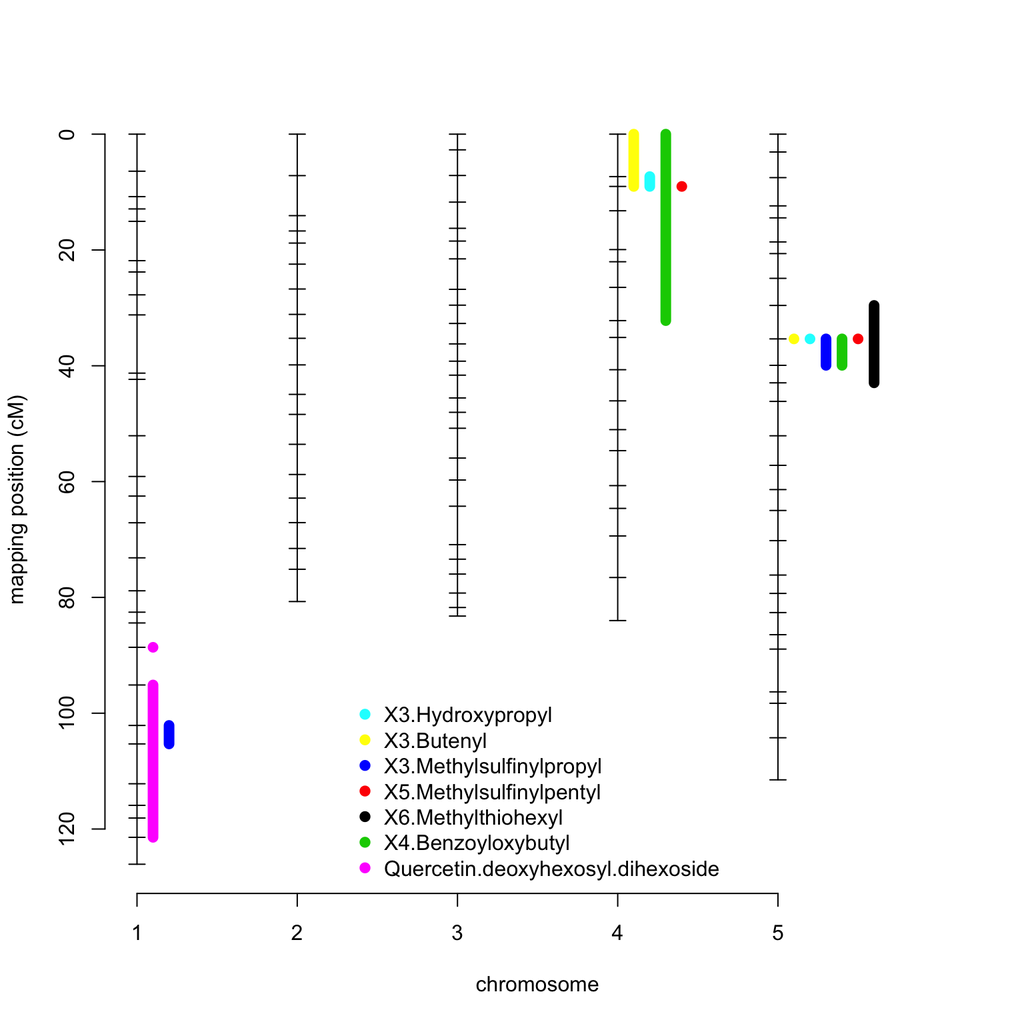

```r
segmentsOnMap(cross=cross, phe=cis.df$phe, chr=cis.df$chr, l = cis.df$lowposition, h =cis.df$highposition,
              lwd = 8, segSpread=.1)
```

#### Thinner lines

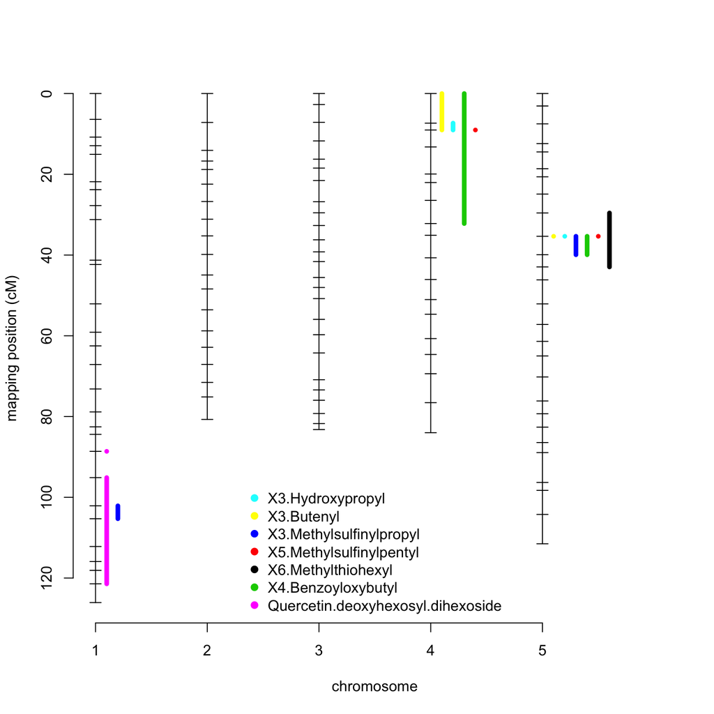

```r
segmentsOnMap(cross=cross, phe=cis.df$phe, chr=cis.df$chr, l = cis.df$lowposition, h =cis.df$highposition,
              lwd = 5, segSpread=.1)
```

#### Closer together

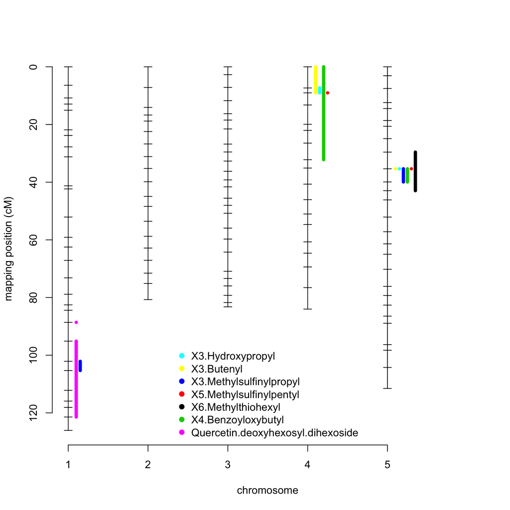

```r
segmentsOnMap(cross=cross, phe=cis.df$phe, chr=cis.df$chr, l = cis.df$lowposition, h =cis.df$highposition,
              lwd = 5, segSpread=.05)
```

#### Smaller legend

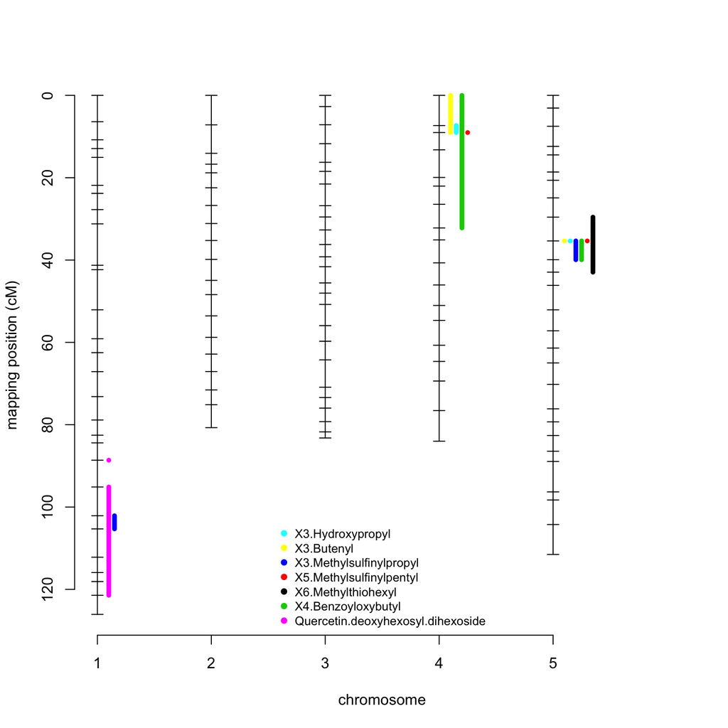

```r
segmentsOnMap(cross=cross, phe=cis.df$phe, chr=cis.df$chr, l = cis.df$lowposition, h =cis.df$highposition,
              lwd = 5, segSpread=.05,  legendCex=.8)
```